# What predicts whether an agent will take an active or passive role in a machine vision situation?

Jill Walker Rettberg

Trying to use machine learning to find clusters. Or, I could try to use machine learning to predict what kinds of character traits lead to cluster 1, 2 or 3.

Inspired by [this tutorial](https://www.r-bloggers.com/2022/02/beginners-guide-to-machine-learning-in-r-with-step-by-step-tutorial/) where they go through how to predict heart disease.

## 0.1 Possible strategies:

1. Make a matrix where the *target* variable (what we are trying to predict) is the cluster. I would need to do a thesaurus sort of some kind to sort ALL the verbs into one of the three clusters based on semantics to get the target. I might also have to make the values for character traits numeric? Perhaps just true or false
2. Easier: predict the *target* of whether a verb is active or negative, since this is really easy to do.
3. or use a different kind of machine learning not to predict but to detect patterns and find the clusters.

# 1 Preparing the data

```r
suppressMessages(library(tidyverse))
suppressMessages(library(multiplex)) # think this is to make adjacency network?
                                        # actually no that's igraph


#Import characters file (../data/Characters.csv)
#define column types and factors
AllCharacters <- read_csv(
  "https://github.com/jilltxt/HumansRobotsAndMachineVision/raw/main/data/characters.csv",
  col_types = cols(
    CharacterID = col_integer(),
    Character = col_character(),
    Species = col_factor(levels = c(
      "Animal", "Cyborg", "Fictional",
      "Human", "Machine", "Unknown")),
    Gender = col_factor(levels = c(
      "Female","Male","Non-binary or Other", "Trans Woman",
      "Unknown")),
    RaceOrEthnicity = col_factor(levels = c(
      "Asian", "Black", "Person of Colour", "White", "Immigrant", "Indigenous",
      "Complex", "Unknown")),
    Age = col_factor(levels = c(
      "Child", "Young Adult", "Adult", "Elderly",
      "Unknown")),
    Sexuality = col_factor(levels = c(
      "Homosexual", "Heterosexual", "Bi-sexual", "Other",
      "Unknown")),
    IsGroup = col_logical(),
    IsCustomizable = col_logical()
  )
)

# Define Characters as the subset of AllCharacters that are not group characters or
# customizable characters.
#
# Convert "Unknown" values to NA.
#
# Select relevant columns.

Characters <- AllCharacters %>%
        filter(IsCustomizable == FALSE) %>%
        na_if("Unknown") %>%
        select(Character, Species, Gender, Sexuality,
               RaceOrEthnicity, Age)

# To figure out what these characters actually do with the machine vision we need
# to load data about the Situations in which they interact with machine vision
# technologies in the creative works in our sample.
#
# The following code imports data about the Situations from situations.csv,
# sets the column types, and also tells R to skip the columns we’re not going
# to need for this analysis.

# NB characterID isn't in this export, fix later (add column back in)
# Also remove GenreID later

Situations <- read_csv(
  "https://raw.githubusercontent.com/jilltxt/HumansRobotsAndMachineVision/main/data/situations.csv",
  col_types = cols(
    SituationID = col_integer(),
    SituationTitle = col_skip(),
    Genre = col_character(),
    Character = col_character(),
    Entity = col_character(),
    Technology = col_character(),
    Verb = col_character()
  )
)

# Add column stating whether verb is active or passive.
# Call this column "target" since this is the target or outcome we want to build
# a model to predict from the other variables. This variable is TRUE for active
# verbs (ending in -ing) and FALSE for passive verbs (ending in -ed)

Situations <- Situations %>%
        mutate(target = (str_detect(Verb, "ing"))) %>%
        filter(!is.na(Verb))

# Filter just the three main genres - since narratives have subgenres (Movie,
# Novel, etc) there would be a lot of duplicate info if we kept them.

# The fifth row has an NA in the Character and CharacterID columns - that
# means that there is no value there. The verb in the verb column belongs
# to an Entity or a Technology, not to a Character. We need to delete all the
# rows with missing data.

Character_situations <- Situations %>%
        select(SituationID, Genre, Character, Verb, target) %>%
        filter(!is.na(Character))


# Now we combine the two dataframes using the CharacterID (for now: Character)
# column as the shared information.
Character_verbs <- merge(
        x = Character_situations, y = Characters,
        by = "Character") %>%
                        # replace w/CharID later
        select(Character, SituationID, Genre, Verb, Species, Gender,
                RaceOrEthnicity, Age, Sexuality, target)

head(Situations)
```

```
## # A tibble: 6 × 7
##   SituationID Genre     Character                 Entity Technology Verb  target
##         <int> <chr>     <chr>                     <chr>  <chr>      <chr> <lgl>
## 1        3269 Narrative Han Solo                  <NA>   <NA>       Lear… TRUE
## 2        3269 Narrative C-3PO                     <NA>   <NA>       Info… FALSE
## 3        3269 Narrative <NA>                      <NA>   Holograms  Mapp… TRUE
## 4        3269 Narrative Leia Skywalker Organa So… <NA>   <NA>       Lear… TRUE
## 5        3269 Narrative Han Solo                  <NA>   <NA>       Plan… TRUE
## 6        3269 Narrative C-3PO                     <NA>   <NA>       Lear… TRUE
```

I want to predict whether an action will be passive or active based on whether it is a technology, entity or character, and on what kind of technology, entity of character it is. The final column in this table, “target”, is TRUE if the verb is active (ends with -ing) and FALSE if it is passive (ends with -ed). We also have a subset of all the situation data which just has the characters with their traits. Here are the first few lines of this:

```r
head(Character_verbs)
```

```
##         Character SituationID     Genre          Verb Species Gender
## 1 "3D Binna Choi"        2831       Art Reconstructed   Human Female
## 2 "3D Binna Choi"        2831       Art        Posing   Human Female
## 3 "3D Binna Choi"        2831       Art       Scanned   Human Female
## 4       "50 Cent"         503 Narrative      Stalking   Human   Male
## 5       "50 Cent"         503 Narrative        Aiming   Human   Male
## 6       "50 Cent"         503 Narrative        Spying   Human   Male
##   RaceOrEthnicity   Age    Sexuality target
## 1           Asian Adult         <NA>  FALSE
## 2           Asian Adult         <NA>   TRUE
## 3           Asian Adult         <NA>  FALSE
## 4           Black Adult Heterosexual   TRUE
## 5           Black Adult Heterosexual   TRUE
## 6           Black Adult Heterosexual   TRUE
```

# 2 Quick visual check of how the data is distributed

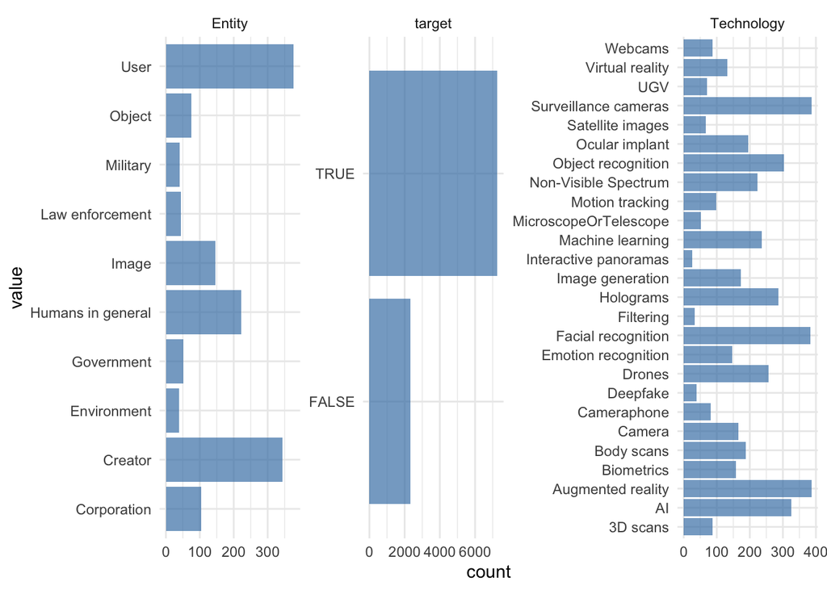

```r
Situations %>%
        select(Entity, Technology, target) %>%
        gather() %>%
        drop_na() %>%
  ggplot(aes(x=value), na.rm = TRUE) +
  geom_bar(fill="steelblue", alpha=.7) +
  theme_minimal() +
        coord_flip() +
  facet_wrap(~key, scales="free")
```

Useful: There are many more active than passive actions. This could be to do with the way we have conceived of situations.

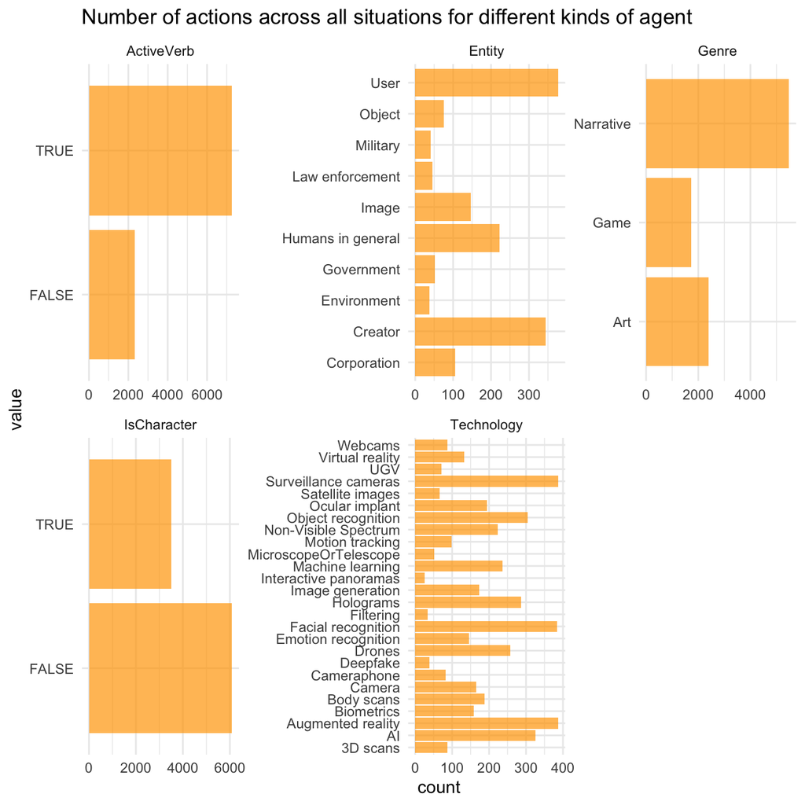

```r
Situations %>%
        mutate(IsCharacter=!is.na(Character)) %>%
        mutate(ActiveVerb = target) %>%
        select(Entity, IsCharacter, Technology, ActiveVerb, Genre) %>%
        gather() %>%
        filter(!is.na(value)) %>%
  ggplot(aes(x=value), na.rm = TRUE) +
  geom_bar(fill="orange", alpha=.7) +
  coord_flip() +
  theme_minimal() +
  facet_wrap(~key, scale="free") +
        labs(title ="Number of actions across all situations for different kinds of agent")
```

TO DO: - make new df with year, country, include this data - one table with data on active/passive, entity/character/tech, genre - then another breaking down further.

Let’s take a quick look at the characters.

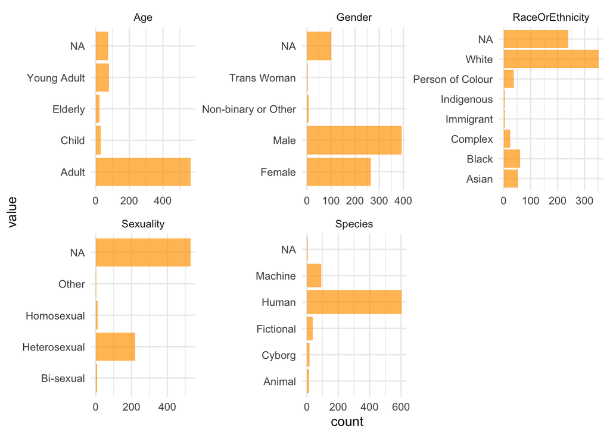

```r
Characters %>%
        select(Species, Gender,
                RaceOrEthnicity, Age, Sexuality) %>%
        gather() %>%
  ggplot(aes(x=value)) +
  geom_bar(fill="orange", alpha=.7) +
  theme_minimal() +
        coord_flip() +
  facet_wrap(~key, scales="free")
```

## 2.1 Another strategy: make the data quantitative

We can make a table listing a verb on each row, and the percentage of times it is used by a character who is female, male, human etc.

But what to do with this once we have it?

```r
Character_verbs_pct <- Character_verbs %>%
        select(Verb, Gender, Species, RaceOrEthnicity, Age, Sexuality, Genre) %>%
        pivot_longer(cols= -Verb,
                names_to = "variable",
                values_to = "value") %>%
        drop_na() %>%
        group_by(Verb) %>%

        summarize(pct_female = mean(value == "Female", na.rm=TRUE),
                  pct.male = mean(value == "Male", na.rm=TRUE),
                  pct.trans = mean(value == "Trans Woman", na.rm=TRUE),
                  pct.human = mean(value == "Human", na.rm=TRUE),
                  pct.robot = mean(value == "Machine"|value=="Cyborg", na.rm=TRUE),
                  pct.animal = mean(value == "Animal", na.rm=TRUE),
                  pct.fictional = mean(value == "Fictional", na.rm=TRUE),
                  pct.asian = mean(value == "Asian", na.rm=TRUE),
                  pct.white = mean(value == "White", na.rm=TRUE),
                  pct.black = mean(value == "Black", na.rm=TRUE),
                  pct.PoC.other = mean(value == "Immigrant"|
                                               value == "Indigenous"|
                                               value == "Complex"|
                                               value == "Person of Colour", na.rm=TRUE),
                  pct.heterosexual = mean(value == "Heterosexual", na.rm=TRUE),
                  pct.homosexual = mean(value == "Homosexual", na.rm=TRUE),
                  pct.sexuality.other = mean(value == "Bi-sexual"|
                                                     value == "Other", na.rm=TRUE),
                  pct.child = mean(value == "Child", na.rm=TRUE),
                  pct.young.adult = mean(value == "Young Adult", na.rm=TRUE),
                  pct.adult = mean(value == "Adult", na.rm=TRUE),
                  pct.elderly = mean(value == "Elderly", na.rm=TRUE),
                  pct.narrative = mean(value == "Narrative", na.rm=TRUE),
                  pct.art = mean(value == "Art", na.rm=TRUE),
                  pct.game = mean(value == "Game", na.rm=TRUE))

# Now add the target (ActiveVerb is TRUE or FALSE)

Character_verbs_pct <- Character_verbs_pct %>%
        mutate(target = (str_detect(Verb, "ing"))) # add target column

# Tried making a correlation matrix, but it's clearly pointless, it just says stuff
# like "-0.76 correlation between male and female" which yeah, obviously they're
# negatively correlated and it's not -1 because there are other gender options.
# Sigh.
#
# How do I even use this table?

# cormat <- cor(Character_verbs_pct %>% keep(is.numeric))

# cormat %>%
#        as.data.frame %>%
#        mutate(var2=rownames(.)) %>%
#  pivot_longer(!var2, values_to = "value") %>%
#  ggplot(aes(x=name,y=var2,fill=abs(value),label=round(value,2))) +
#  geom_tile() + geom_label() + xlab("") + ylab("") +
#  ggtitle("Correlation matrix of our predictors") +
#  labs(fill="Correlation\n(absolute):")
```

# 3 Likely predictors of whether the verb is active or passive

## 3.1 Character traits and active/passive actions

To quickly get an idea of which character traits might predict whether a verb is active (“watching”) or passive (“watched”) we can run barcharts showing the distribution of each trait

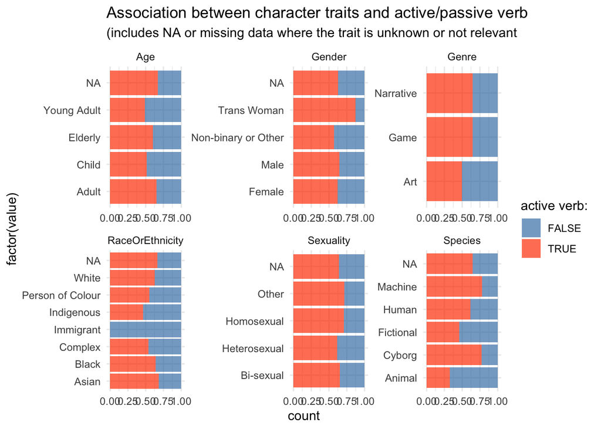

```r
Character_verbs %>% select(Genre, Species, Gender,
                RaceOrEthnicity, Age, Sexuality, target) %>%
        pivot_longer(!target, values_to = "value") %>%
        ggplot(aes(x=factor(value), fill=factor(target))) +
        scale_fill_manual(values=c("steelblue", "orangered1")) +
        geom_bar(position="fill", alpha=.7) +
        theme_minimal() +
        labs(fill="active verb:", title ="Association between character traits and active/passive verb",
             subtitle="(includes NA or missing data where the trait is unknown or not relevant") +
        coord_flip() +
        facet_wrap(~name, scales="free")
```